# HSC Survey Results

# Scots Bay Survey # 3 Results from 18/06/2023

## Survey Details

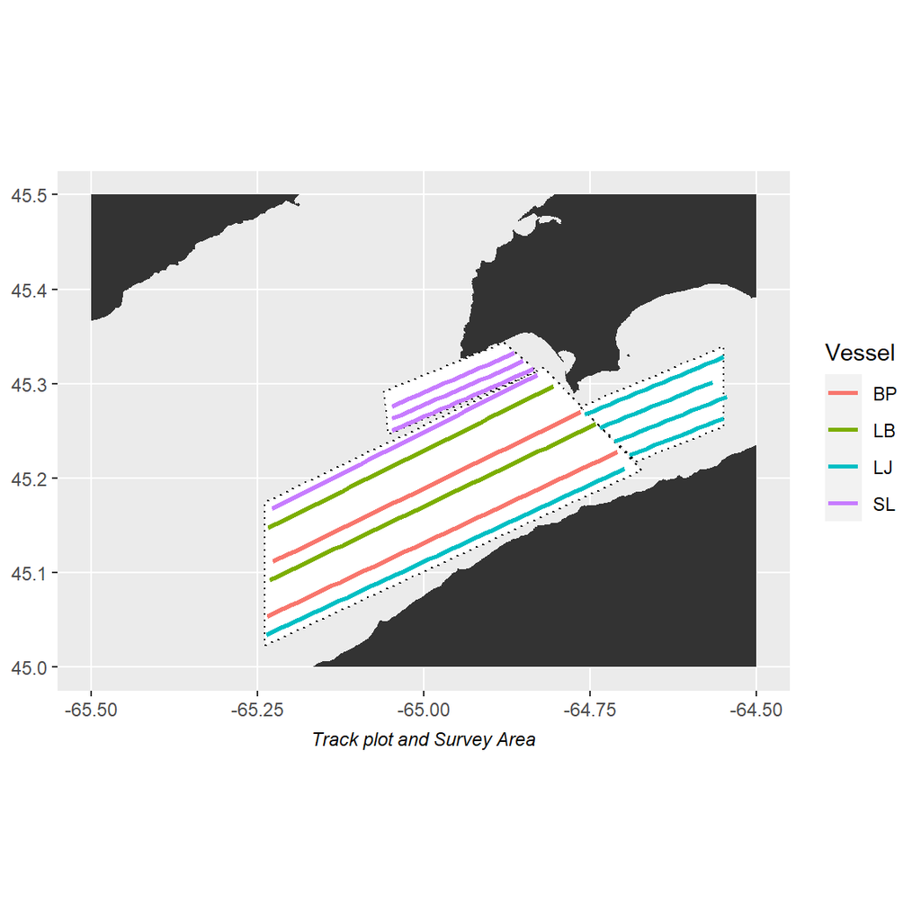

There was a plankton tow and replicate conducted and CTD cast by Lady Janice II.

A total of 150 tags were applied during the survey over 1 events from 2023-06-19 to 2023-06-19 from 1 vessels.

Samples were obtained for target strength estimation.

### Tides Tables

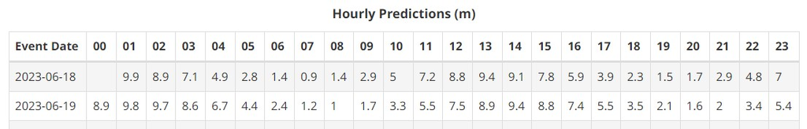

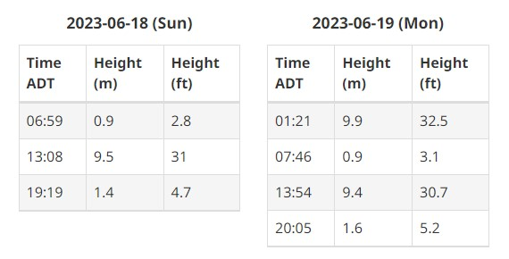

Tide Schedule for Margaretsville NS, Station #315, Source: www.waterlevels.gc.ca

### Acoustic Equipment

Each vessel was equipped with a Simrad ES38-18/200-18C combi (2-in-1) transducer prior to the survey that contains a 38kHz split beam and 200 kHz single beam transducer. Data was logged to the computer hard-drive for post-processing. All participating boats were calibrated on 38kHz before the survey.

## Survey Results

### Main Results

The results are subject to change as DFO will re-evaluate data editing, area estimation and apply a target strength.

**Preliminary biomass prediction for Scots Bay using standardized parallel transects is 34,279mt, and with turnover applied 15,158mt.**

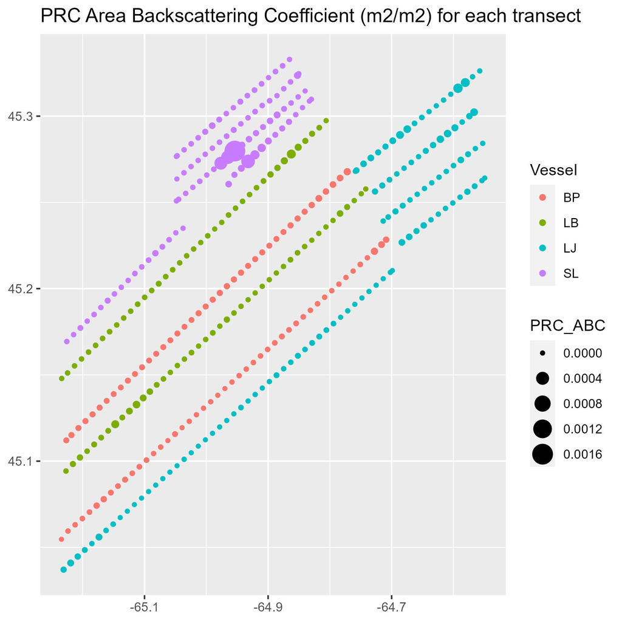

### Transect Details

Table 1: Transect Details

| Vessel | Transect # | Date/Time Start | Date/Time End | Start Lon | Start Lat | End Lon | End Lat | Location | Distance (km) | Speed |
| --- | --- | --- | --- | --- | --- | --- | --- | --- | --- | --- |
| BP | T01 | 2023-06-19 01:19:45 | 2023-06-19 04:06:07 | -65.236 | 45.054 | -64.709 | 45.228 | SB | 45.78 | 8.92 |
| BP | T02 | 2023-06-19 04:34:07 | 2023-06-19 07:11:38 | -64.764 | 45.270 | -65.227 | 45.112 | SB | 40.40 | 8.31 |
| LB | T01 | 2023-06-19 00:20:31 | 2023-06-19 02:57:02 | -65.232 | 45.092 | -64.742 | 45.258 | SB | 43.11 | 8.92 |
| LB | T02 | 2023-06-19 03:41:11 | 2023-06-19 06:09:44 | -64.806 | 45.298 | -65.234 | 45.148 | SB | 37.89 | 8.26 |
| LJ | T01 | 2023-06-19 00:25:21 | 2023-06-19 03:13:50 | -65.237 | 45.034 | -64.699 | 45.210 | SB | 46.86 | 9.01 |
| LJ | T02 | 2023-06-19 03:24:37 | 2023-06-19 04:07:01 | -64.691 | 45.225 | -64.549 | 45.264 | SB | 12.01 | 9.18 |
| LJ | T03 | 2023-06-19 04:15:32 | 2023-06-19 05:12:23 | -64.545 | 45.287 | -64.714 | 45.239 | SB | 14.40 | 8.21 |
| LJ | T04 | 2023-06-19 05:22:22 | 2023-06-19 06:14:19 | -64.735 | 45.254 | -64.567 | 45.302 | SB | 14.36 | 8.96 |
| LJ | T05 | 2023-06-19 06:28:02 | 2023-06-19 07:24:14 | -64.549 | 45.329 | -64.759 | 45.268 | SB | 17.84 | 10.29 |
| SL | T01 | 2023-06-19 01:24:22 | 2023-06-19 03:42:03 | -65.229 | 45.168 | -64.830 | 45.310 | SB | 36.57 | 8.61 |
| SL | T02 | 2023-06-19 03:47:35 | 2023-06-19 05:01:48 | -64.836 | 45.316 | -65.048 | 45.251 | SB | 18.71 | 8.17 |
| SL | T03 | 2023-06-19 05:06:50 | 2023-06-19 06:05:40 | -65.048 | 45.264 | -64.850 | 45.325 | SB | 17.22 | 9.48 |
| SL | T04 | 2023-06-19 06:11:44 | 2023-06-19 07:15:08 | -64.864 | 45.333 | -65.048 | 45.277 | SB | 16.18 | 8.27 |

### Survey Summary

Table 2: Acoustic Survey Results

| Vessel | Transect No. | Target Strength (db/kg) | Mean Sa (/m2) | Biomass Density (kg/m2) |
| --- | --- | --- | --- | --- |
| SL | T02 | -35.5 | -38.714 | 0.477 |
| SL | T01 | -35.5 | -46.237 | 0.084 |
| LJ | T05 | -35.5 | -46.645 | 0.077 |
| LJ | T04 | -35.5 | -48.806 | 0.047 |
| BP | T02 | -35.5 | -51.467 | 0.025 |
| LB | T02 | -35.5 | -51.933 | 0.023 |
| LJ | T02 | -35.5 | -52.543 | 0.020 |
| LB | T01 | -35.5 | -52.720 | 0.019 |
| SL | T04 | -35.5 | -55.155 | 0.011 |
| SL | T03 | -35.5 | -55.210 | 0.011 |
| BP | T01 | -35.5 | -55.283 | 0.011 |
| LJ | T03 | -35.5 | -55.566 | 0.010 |
| LJ | T01 | -35.5 | -56.869 | 0.007 |

Note:  
Transects are listed from greatest to least backscatter.

Table 3: Survey Summary Table

| Layer | Target Strength | Area (km2) | Mean Sa | Density (kg/m2) | Biomass (tons) | Percent Area | Percent Biomass | Standard Error (tons) | Standard Error (%) |
| --- | --- | --- | --- | --- | --- | --- | --- | --- | --- |
| Main Box | -35.5 | 661 | -51.2873 | 0.0282 | 17,436.999 | 77.8 | 50.9 | 7,661.36 | 43.94 |
| Northern Box | -35.5 | 66 | -42.9904 | 0.1662 | 11,762.735 | 7.8 | 34.3 | 10,260.21 | 87.23 |
| Eastern Box | -35.5 | 123 | -49.3407 | 0.0383 | 5,079.653 | 14.5 | 14.8 | 1,847.82 | 36.38 |

### Greatest Backscatter

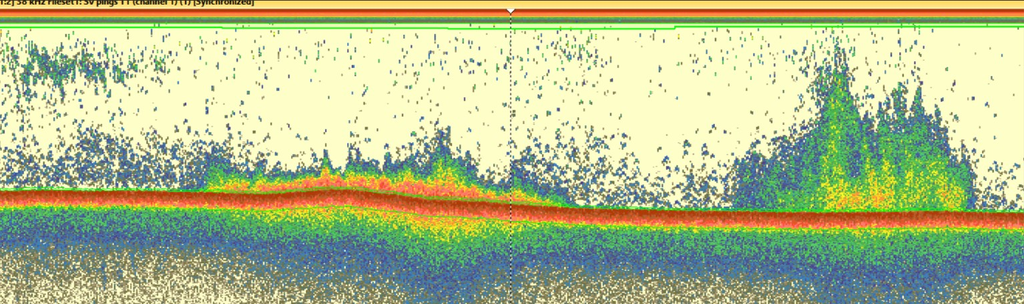

A snip from the transect with the greatest backscatter

The single point with the largest backscatter density (PRC) was recorded by **SL**, at the following location:

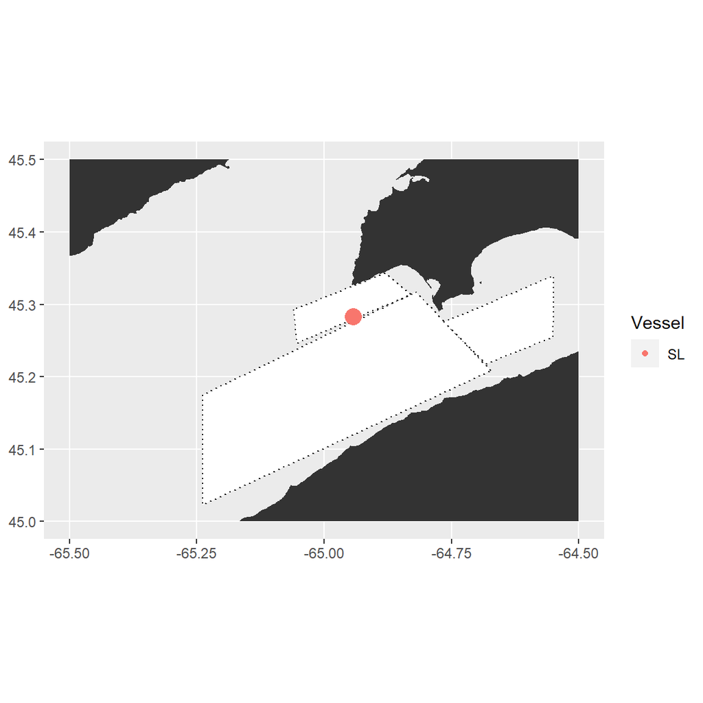

[figure not shown]

A snip from the transect with the greatest backscatter

The transect with the overall largest biomass was recorded by **SL**, at the following location:

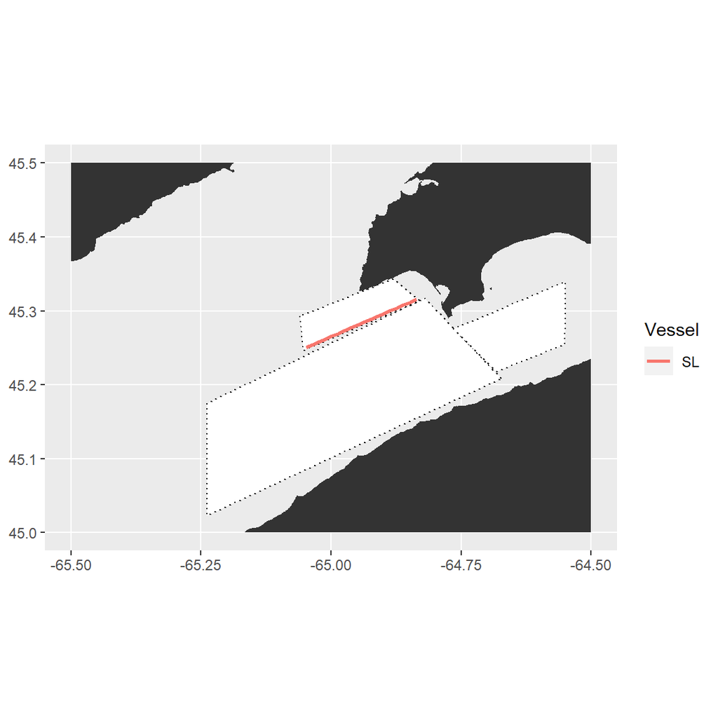

### Annual Summaries

Table 4: Annual Comparison Table

| Ground | Survey Number | Current Year Survey Date | Current Year HSC Estimate | Current Year HSC Turnover Adjusted | Previous Year Survey Date | Previous Year HSC Estimate | Previous Year HSC Turnover Adjusted | Previous Year DFO Estimate | Previous Year DFO Turnover Adjusted |
| --- | --- | --- | --- | --- | --- | --- | --- | --- | --- |
| Scots Bay | 1 | 2023-05-22 | 40,856.00 | 40,856 | 2022-05-29 | 90,746 | 90,746 | 99,092 | 99,092 |
| Scots Bay | 2 | 2023-06-06 | 113,767.33 | 108,783 | 2022-06-12 | 104,368 | 92,111 | 113,792 | 100,407 |
| Scots Bay | 3 | 2023-06-18 | 34,279.39 | 15,158 | 2022-06-26 | 34,199 | 19,781 | 29,429 | 13,709 |
| Scots Bay | 4 | NA | NA | NA | 2022-07-10 | 10,537 | 5,549 | 7,892 | 3,515 |
| Scots Bay | 5 | NA | NA | NA | 2022-07-26 | 13,060 | 11,904 | 11,402 | 10,536 |
| Scots Bay | 6 | NA | NA | NA | 2022-08-07 | 5,250 | 3,067 | 6,150 | 4,248 |
| Scots Bay | 7 | NA | NA | NA | 2022-08-21 | 4,392 | 3,453 | 4,688 | 3,656 |
| Scots Bay | 8 | NA | NA | NA | 2022-09-05 | 21,908 | 21,372 | 21,420 | 20,848 |
| Scots Bay | 9 | NA | NA | NA | 2022-09-18 | 8,133 | 4,850 | 7,283 | 0 |
| Scots Bay | 10 | NA | NA | NA | 2022-10-03 | NA | NA | 4,152 | 0 |

Table 5: Annual Summary Table

| Year | Ground | HSC Estimate | HSC Turnover Adjusted | DFO Estimate | DFO Turnover Adjusted |
| --- | --- | --- | --- | --- | --- |
| 2022 | Scots Bay | NA | NA | 305,300 | 256,011 |
| 2023 | Scots Bay | 188,902.7 | 164,797 | NA | NA |

## Tagging, Plankton, and CTD Data

### Tag Data

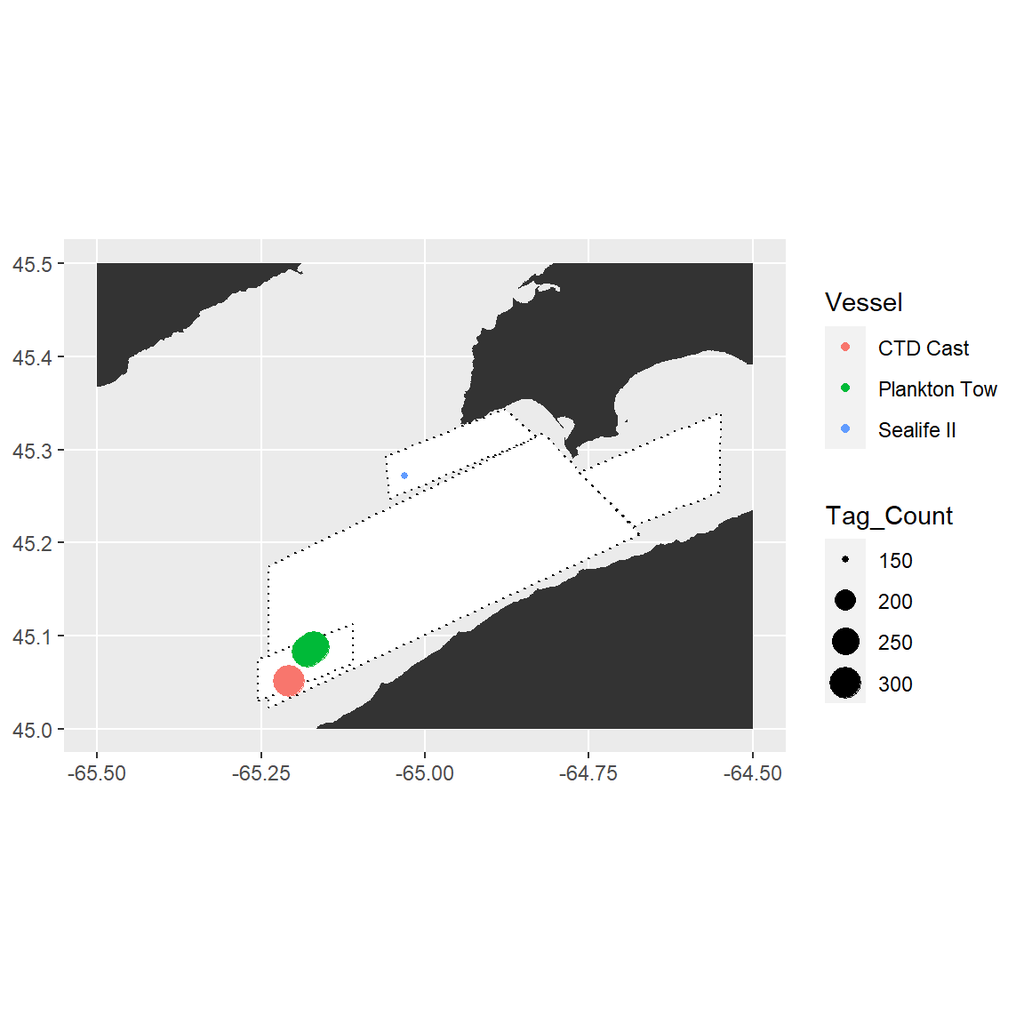

| Vessel | Tags |
| --- | --- |
| Sealife II | 150 |

### Plankton Data

#### Tow Summary Table

|  | Tow 1 | Tow 2 |
| --- | --- | --- |
| **Base Details** |  |  |
| Vessel | Lady Janice II | Lady Janice II |
| Set Number | SB2023-05 | SB2023-06 |
| Ground | SB | SB |
| Date | 18/06/2023 | 18/06/2023 |
| Wind Direction (km/h) | W | W |
| Swell (m) | 0.25 | 0.25 |
| Air Temp (c) | 6 | 6 |
| **Tow Details** |  |  |
| Tow Start | 07:46:00 | 08:00:00 |
| Tow End | 07:56:00 | 08:10:00 |
| Start Lat | 45.08783 | 45.08250 |
| End Lat | 45.08750 | 45.07667 |
| Start Lon | -65.17000 | -65.17833 |
| End Lon | -65.17800 | -65.18333 |
| Avg Tow Depth (m) | NA | NA |
| Speed | 2.2 | 2.4 |
| Heading | 264 | 208 |
| Tide Direction | with | with |
| **Other Data Collection** |  |  |
| Flow Start | 374505 | 398897 |
| Flow End | 398897 | 428899 |
| No. Revolutions | 24392 | 30002 |
| Distance (m) | 655.4862 | 806.2437 |
| Volume | 2059.210 | 2532.815 |
| Secchi Disappear (m) | 9 | 9 |
| Secchi Reappear (m) | 8 | 8 |

#### Captured plankton

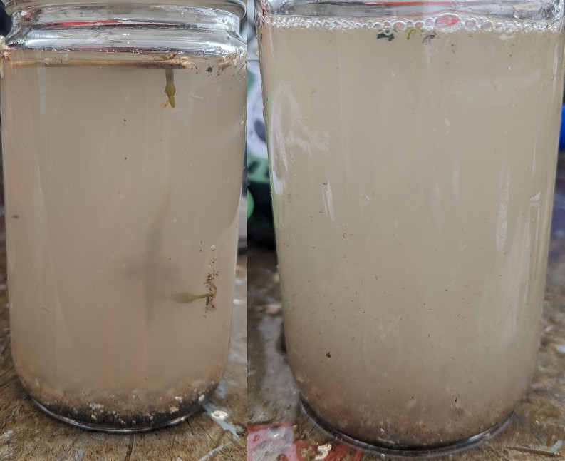

Captured plankton from the surface tows

### CTD Data

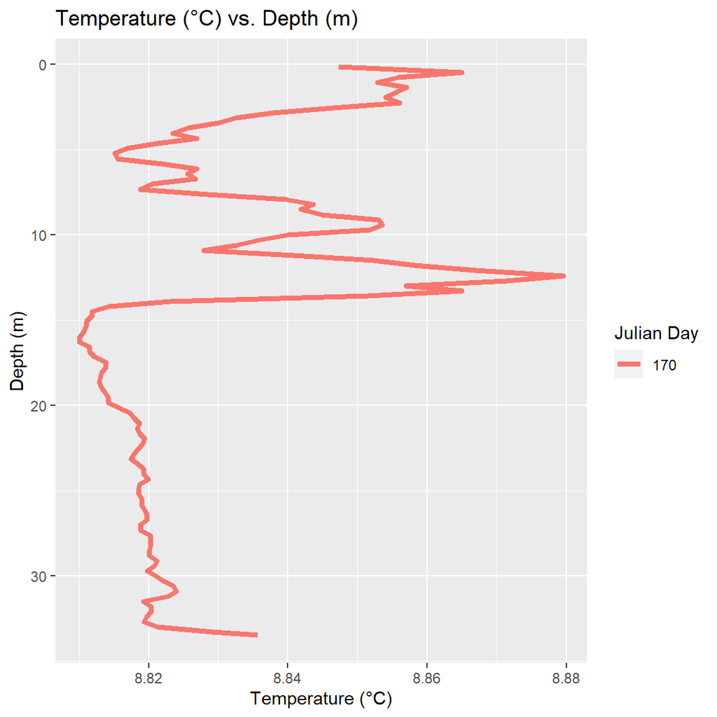

CTD depth profiles for all 2023 Scots Bay surveys so far.

#### Sea surface temperatures

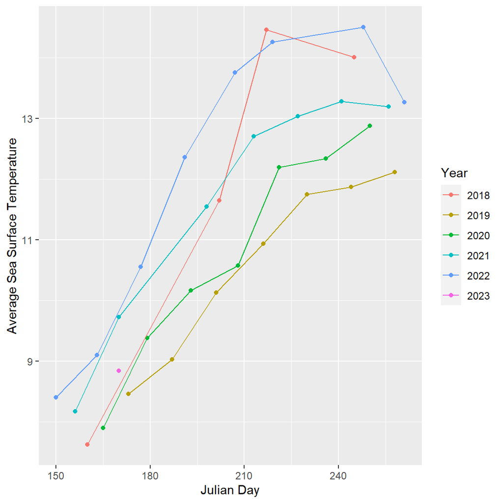

Annual average sea surface temperatures (SST) for Scots Bay.

## Vessel Performance

### Speed

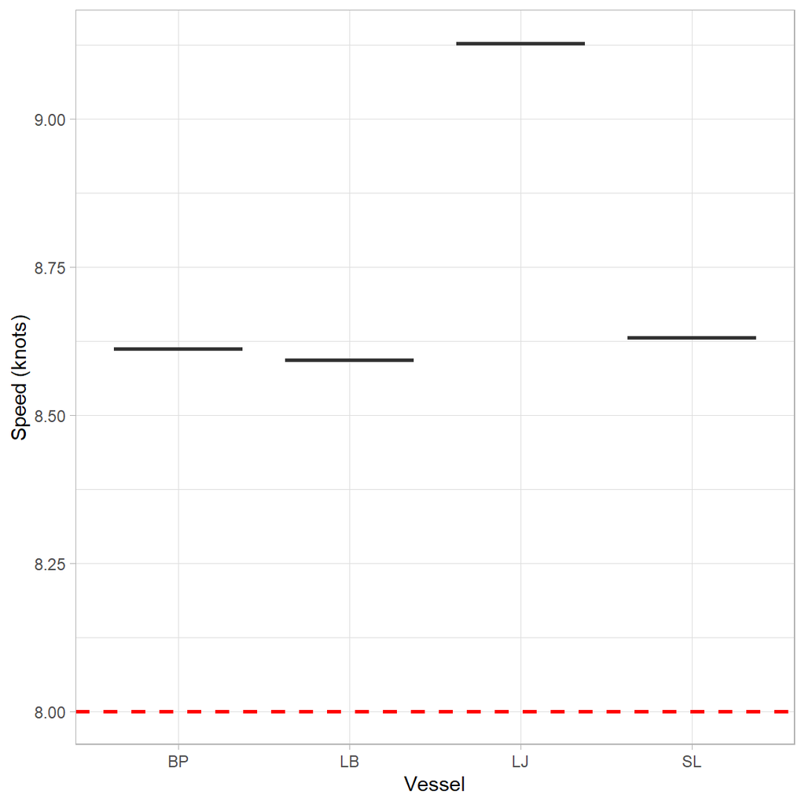

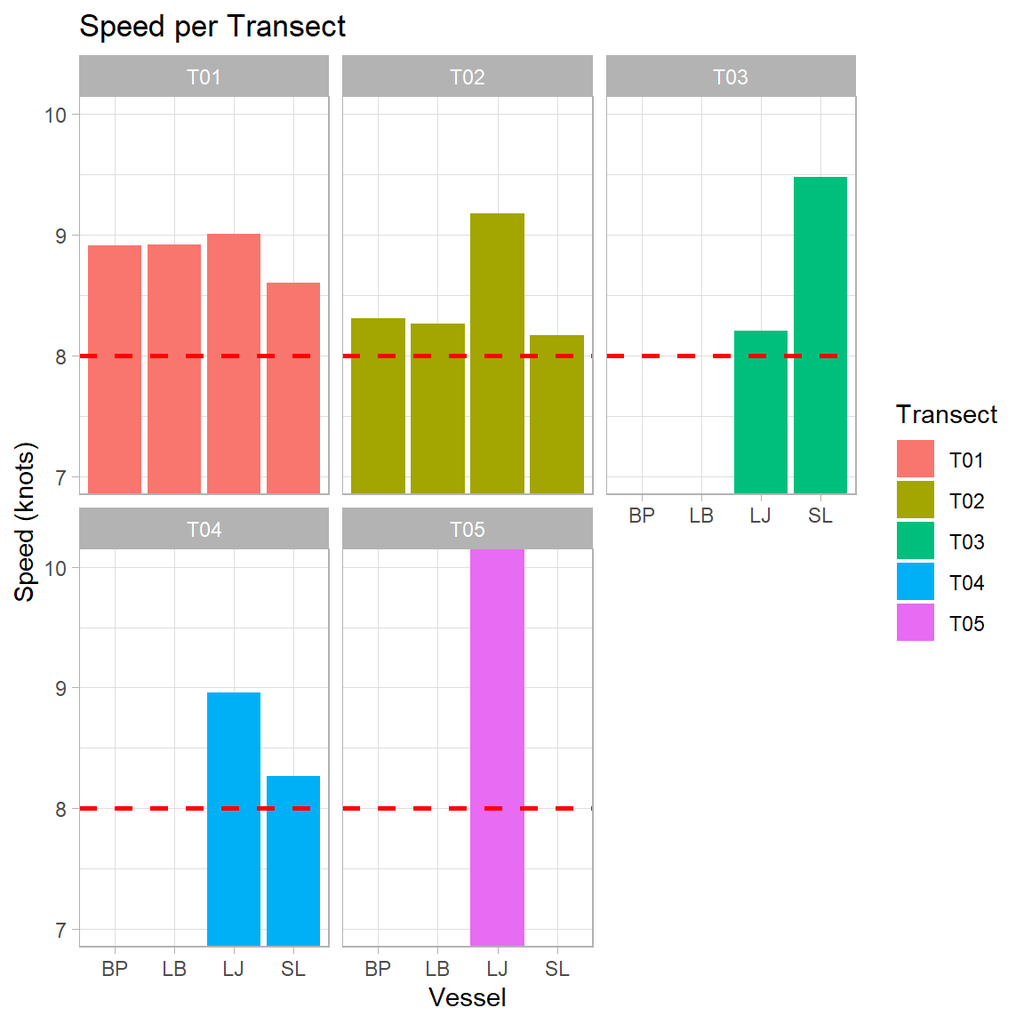

Average vessel speed was 8.74. This is above the 8 knot requirement; vessels are urged to slow down to prevent backscatter noise from interfering with the acoustic data.

### Distance

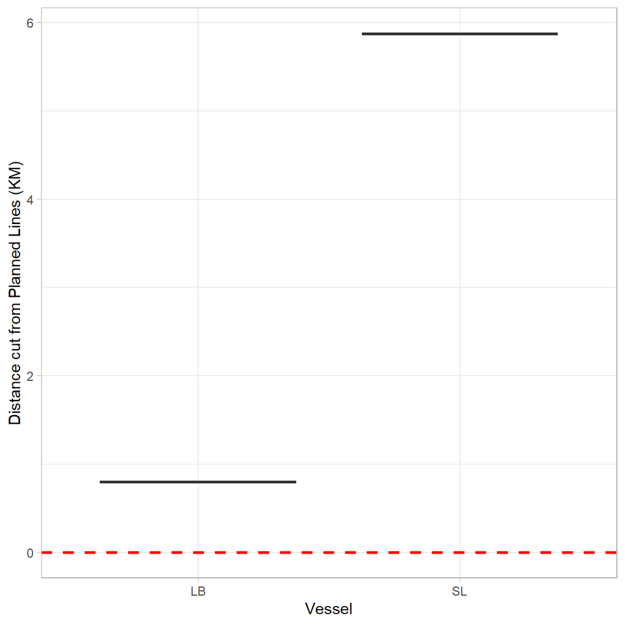

More than 2km of distance was cut from the planned lines; vessels are reminded to complete their assigned lines straight and without deviating or cutting corners short.